# Gaussian Process Emulation of FPSO motion simulators

Lachlan Astfalck

January 16, 2019

This document demonstrates the research presented in Chapter 4. First, a synthetic dataset is generated, then demonstration of the emulation methodology is presented, finally the diagnostics for the results are given.

# Generation of synthetic dataset

As the original dataset used within the research is confidential, the methodologies presented are demonstrated herein using a synthetic dataset. The dataset is generated so as to be similar to the original data, albeit in a smaller dimensional space. This is to reduce the computational demands for the point of this tutorial. It is straightforward to extend this code incorporate higher dimensions, more input data, and variations of linear-circular inputs.

First we select the number of training and validation points, and number of dimensions that we wish to build the emulator in.

```r
N <- 500
N_predict <- 500
N_total <- N + N_predict
dim <- 5
```

Then, a random Latin hypercube sample of length `N_total` is generated over a $dim$-dimensional hypercube from the package `lhs`. Note that unlike the original research, this process does not induce any correlations or dependencies in the synthesised data.

```r
X_LHS <- maximinLHS(N_total, dim)
```

`N` points are randomly sampled from the Latin hypercube sample. These points act as the training data, and the remainder act as validation points.

```r
sample_index <- sample(seq(1, N_total, 1), N, replace = FALSE)

X_train <- X_LHS[sample_index, ]
X_predict <- X_LHS[-sample_index, ]

X_all <- rbind(X_train, X_predict)
```

The Latin hypercube generates $d$-dimensional points in $[0,1]^d$. To demonstrate the developments presented in the research, 2 of the input dimensions are redefined on a circular domain with the dimensions scaled to $[0,2\pi]$. We do this by specifying a vector defining the type of input along each dimension (this seems odd, but becomes useful later), and multiplying the circular dimensions by $2\pi$.

```r
types <- c("circular", "circular", "linear", "linear", "linear")
circ_index <- which(types == "circular")

X_all[ ,circ_index] <- X_all[ ,circ_index] * 2 * pi
```

Hyper-parameter values are now specified in the vector `hp_true`. Random values have been chosen. Next, a list of distance matrices is calculated. `dist.circular()` from the package `circular` is used to calculate the distance matrix of the circular parameters. The covariance matrices for each dimension are easily calculated from the distance matrix, and the final covariance matrix is calculated as an element-wise product of each of the separate covariance matrices. Here we use a squared-exponential covariance function along the linear inputs:
$$c_{SE}(x_n,x_n';\rho_n) = \exp\left( -\frac{|x_n-x_n'|^2}{2\rho_n} \right), \hspace{5mm} \rho_n > 0,$$
a $C^4$–Wendland function along the circular inputs:
$$c_{C4}(x_m,x_m';\tau_m) = \left( 1 + \tau_m\frac{d(x_m,x_m')}{\pi} + \frac{(\tau_m^2-1)}{3} \frac{d(x_m,x_m')^2}{\pi^2}\right) \left(1 - \frac{d(x_m,x_m')}{\pi} \right)^{\tau_m}_+,$$
and combine these into a single covariance function via a product of correlation functions:
$$c(\textbf{x},\textbf{x}';\boldsymbol{\theta}) = \prod_{m=1}^4c_{C^4}(x_m,x_m';\boldsymbol{\theta})\prod_{n=5}^{10}c_{SE}(x_n,x_n';\boldsymbol{\theta}).$$

```r
hp_true <- c(6.5, 7.5, 2, 3, 1, 1, 0.005)

SE <- function(d,alpha,rho) {
  alpha * exp(-d^2/(2*rho))
}

C4_Wend <- function(d,tau) {
  (1 + tau * d/pi + (tau^2 - 1)/3 * (d^2)/(pi^2)) * pmax((1 - d/pi)^tau, 0)
}

d <- list()
K_ind_true <- list()
for (i in 1:length(types)) {
    if(types[i] == "circular") {
        options(warn = -1)
        d[[i]] <- as.matrix(dist.circular(X_all[ ,i], method = "geodesic"))
        K_ind_true[[i]] <- C4_Wend(d[[i]], hp_true[i])
        options(warn = 0)
    } else {
        d[[i]] <- as.matrix(dist(X_all[ ,i]))
        K_ind_true[[i]] <- SE(d[[i]], 1, hp_true[i])
    }
}

K_all_true <- matrix(hp_true[dim+1], N_total, N_total)
for (i in 1:dim) {K_all_true <- K_all_true * K_ind_true[[i]]}
K_all_true <- K_all_true + diag(hp_true[dim+2], N_total, N_total)
```

Finally, we generate our synthetic data by drawing a single sample from a zero-mean multivariate-normal distribution with `K_all_true` set as the variance-covariance matrix.

```r
y_synth <- as.matrix(rmvnorm(1,rep(0,N_total),K_all_true))
y_samples <- y_synth[1, 1:N]
y_predict <- y_synth[1, (N+1):(N_total)]
```

# Emulation methodology

This section is presented in two parts: the first focuses on the estimation of the hyper-parameter values, and the second on the prediction of the validation data.

## Finding *maximum-a-posteriori* estimates of hyperparameters

To estimate the hyper-parameter values, we solve for the values that maximise the posterior. Note that here we use simplification of Equation A.4.7 for the case when the mean function $H\beta$ is not considered, and $n^*$ is sufficiently large to approximate the $t$-distribution with a Gaussian distribution. The posterior is expressed as a proportionality as the constants will not affect the optimisation routine. The function `log_posterior` takes a vector of hyperparameters, a list of distance matrices, the observed values, and the types vector as an argument and return the log posterior. The function `optimx` from the package `optimx` is then used to solve for the values of `hp` that maximise the function `log_posterior`.

Taking the exponential of the parameters given to `optimx` allows for `optimx` to search over $\mathcal{R}^d$ for parameter values, and then constrains them to be positive (and $\geq 6$ for the circular parameters).

```r
log_posterior <- function(hp, d_xx, y_samples, types){

  circ_index <- which(types == "circular")
  hp[circ_index] <- exp(hp[circ_index]) + 6
  hp[-circ_index] <- exp(hp[-circ_index])

  k_xx_sample <- list()
  for (i in 1:length(types)) {
    if(types[i] == "circular") {
        options(warn = -1)
        k_xx_sample[[i]] <- C4_Wend(d_xx[[i]], hp[i])
        options(warn = 0)
    } else {
        k_xx_sample[[i]] <- SE(d_xx[[i]], 1, hp[i])
    }
  }

  k_dim <- dim(k_xx_sample[[1]])[1]
  k_xx_all <- matrix(hp[length(types)+1], k_dim, k_dim)
  for (i in 1:length(k_xx_sample)) {k_xx_all <- k_xx_all * k_xx_sample[[i]]}
  k_xx_all <- k_xx_all + diag(hp_true[length(types)+2], k_dim, k_dim)


    dlike <- dmvnorm(y_samples, rep(0,k_dim[1]), k_xx_all, log = TRUE)
    return(-dlike)

}

d_xx <- lapply(d, function(x) x[c(1:N), c(1:N)])

hp_optim = optimx(par = log(c(0.5, 1.5, 2, 3, 1, 1, 0.005)),
                                    fn = log_posterior,
                                    method = "Nelder-Mead",
                                    d_xx = d_xx,
                                    y_samples = y_samples,
                                    types = types)

hp_MAP <- exp(coef(hp_optim))
hp_MAP[circ_index] <- hp_MAP[circ_index] + 6
print(hp_MAP)
```

```
##                  p1       p2       p3       p4        p5        p6
## Nelder-Mead 6.63838 8.021369 2.161145 6.931255 0.8564401 0.9374952
##                      p7
## Nelder-Mead 0.008116238
```

## Predicting using the emulator

First the covariance variance matrix is partitioned into $K$, $K_{*}$, and $K_{**}$, and $K^{-1}$ and $(\text{Cholesky}({K}))^{-1}$ are pre-calculated. The estimated parameter values are used for this, and not the assumed values.

```r
K_ind_MAP <- list()
for (i in 1:length(types)) {
    if(types[i] == "circular") {
        options(warn = -1)
        K_ind_MAP[[i]] <- C4_Wend(d[[i]], hp_MAP[i])
        options(warn = 0)
    } else {
        K_ind_MAP[[i]] <- SE(d[[i]], 1, hp_MAP[i])
    }
}

K_all_MAP <- matrix(hp_MAP[length(types)+1], N_total, N_total)
for (i in 1:dim) {K_all_MAP <- K_all_MAP * K_ind_MAP[[i]]}
K_all_MAP <- K_all_MAP + diag(hp_MAP[length(types)+2], N_total, N_total)

k_xx <- K_all_MAP[c(1:N), c(1:N)]
k_xxs <- K_all_MAP[c(1:N), c((N+1):(N_total))]
k_xsxs <- K_all_MAP[c((N+1):(N_total)), c((N+1):(N_total))]
k_xx_inv <- solve(k_xx)
k_xx_chol <- solve(t(chol(k_xx)))
```

```r
M <- t(k_xxs) %*% k_xx_inv %*% as.matrix(y_samples)
Cov <- k_xsxs - crossprod(k_xx_chol %*% k_xxs)
```

This gives the mean function and the variance-covariance matrix for the validation points, trained from the training data. To estimate the validation data we make 1000 random draws from a multivariate normal distribution with mean `M` and variance-covariance matrix `Cov`.

```r
y_draw <- as.matrix(rmvnorm(1000, mean = M, sigma = Cov))
```

`y_draw` now contains $1000 \times 500$ matrix with columns $i$ providing 1000 draws from the distribution of the $i$th predictive point in `y_predict`. We now use these estimates, and the real values of `y_predict` to diagnose the performance of the emulator.

# Diagnostics

Finally we produce the diagnostic plots included in the paper. The functions to produce these plots are included at the bottom of the document.

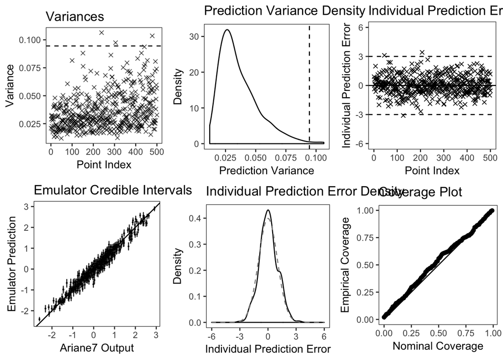

```r
p1 <- var_scatter(y_draw, 0.1 * var(y_samples))
p2 <- coverage_plot(y_draw, y_predict)
p3 <- IPE_plot(y_draw, y_predict)
p4 <- var_density(y_draw, 0.1 * var(y_samples))
p5 <- IPE_density(y_draw, y_predict)
p6 <- cred_intervals(y_draw, y_predict)

grobs <- list(p1, p2, p3, p4, p5, p6)
lay <- rbind(c(1,4,3),
             c(6,5,2))
grid.arrange(grobs = grobs, layout_matrix = lay)
```

```r
var_scatter <- function(y_draw, var_accept) {

    df <- data.frame(index = seq(1,length(y_draw[1,]),1))
    df[ ,2] <- apply(y_draw, 2, var)

    ggplot(df, aes(df[ ,1], df[ ,2])) +
        geom_point(shape = 4, alpha = 0.7) +
        geom_hline(yintercept = var_accept , linetype = 2) +
        xlab("Point Index") +
        ylab("Variance") +
        ggtitle("Variances") +
        theme(panel.grid.major = element_blank(),
                    panel.grid.minor = element_blank(),
                    aspect.ratio = 1)

}


coverage <- function(samples, y_actual) {

    coverage <- data.frame(actual = seq(0,0.99,0.01))

    for (k in 1:100) {
        upper <-  apply(samples, 2, quantile, 0.50 + k/200)
        lower <-  apply(samples, 2, quantile, 0.50 - k/200)

        in_quantile <- 0
        for (m in 1:length(samples[1, ])) {
          if (y_actual[m] < upper[m] & y_actual[m] > lower[m]) {
            in_quantile <- in_quantile + 1
          }
        }
        coverage[k,2] <- in_quantile/length(samples[1, ])
    }
    return(coverage)
}

coverage_plot <- function(samples, y_actual) {

    cov <- coverage(samples, y_actual)

    ggplot(data = cov) +
            geom_line(aes_string(x = colnames(cov)[1], y = colnames(cov)[1])) +
            geom_point(aes_string(x = colnames(cov)[1], y = colnames(cov)[2])) +
            theme_bw() +
            xlab("Nominal Coverage") +
            ylab("Empirical Coverage") +
            ggtitle("Coverage Plot") +
            coord_fixed(ratio = 1) +
            theme(panel.grid.major = element_blank(),
                        panel.grid.minor = element_blank())

}


IPE_plot <- function(samples, y_actual) {

    IPE <- data.frame(index = seq(1,length(y_actual),1))
    E <- apply(samples, 2, mean)
    V <- apply(samples, 2, var)
    IPE[ ,2] <- (y_actual - E) / sqrt(V)

    ggplot(data = IPE) +
        geom_point(aes_string(x = colnames(IPE)[1],
                                                    y = colnames(IPE)[2]),
                                                    shape = 4) +
        geom_hline(yintercept = -3, linetype = 2) +
        geom_hline(yintercept = 0) +
        geom_hline(yintercept = 3, linetype = 2) +
        theme_bw() +
        ylim(-6,6) +
        xlab("Point Index") +
        ylab("Individual Prediction Error") +
        ggtitle("Individual Prediction Errors") +
        theme(panel.grid.major = element_blank(),
                    panel.grid.minor = element_blank(),
                    aspect.ratio = 1)

}


var_density <- function(y_draw, var_accept) {

    V <- data.frame(var = apply(y_draw, 2, var))

    ggplot(V) +
        geom_density(aes(x = var)) +
        geom_vline(xintercept = var_accept , linetype = 2) +
        xlab("Prediction Variance") +
        ylab("Density") +
        ggtitle("Prediction Variance Density") +
        theme(panel.grid.major = element_blank(),
                    panel.grid.minor = element_blank(),
                    aspect.ratio = 1)

}


IPE_density <- function(samples,y_actual) {

    IPE <- data.frame(index = seq(1,length(y_actual),1))
    E <- apply(samples, 2, mean)
    V <- apply(samples, 2, var)
    IPE[ ,2] <- (y_actual - E) / sqrt(V)

    ggplot() +
        geom_density(data = IPE, aes_string(x = colnames(IPE)[2])) +
        geom_line(data = data.frame(x = seq(-6,6,0.01),
                                                                den = dnorm(seq(-6,6,0.01))),
                            aes(x,den),
                            linetype = 2,
                            color = "#8b8b8b") +
        xlim(-6,6) +
        xlab("Individual Prediction Error") +
        ylab("Density") +
        ggtitle("Individual Prediction Error Density") +
        theme(panel.grid.major = element_blank(),
                    panel.grid.minor = element_blank(),
                    aspect.ratio = 1)

}


cred_intervals <- function(y_draw, y_predict){

    df <- data.frame(index = seq(1,length(y_draw[1,]),1))
    df[ ,2] <- apply(y_draw, 2, var)

    output_percentile <- data.frame(y = y_predict,
        quantiles = t(apply(y_draw, 2, quantile, probs = c(0.025,0.25,0.50,0.75,0.975))))

    ggplot(output_percentile, aes(x = y)) +
        geom_boxplot(aes(ymin = quantiles.25.,
                                         lower = quantiles.25.,
                                         middle = quantiles.50.,
                                         upper = quantiles.75.,
                                         ymax = quantiles.75.),
                                 stat = "identity",
                                 alpha = 0.15) +
        geom_point(aes(x = y, y = quantiles.50.), size = 0.2) +
        geom_abline(intercept = 0, slope = 1) +
        xlab("Ariane7 Output") +
        ylab("Emulator Prediction") +
        ggtitle("Emulator Credible Intervals") +
        coord_fixed(ratio = 1) +
        theme(panel.grid.major = element_blank(),
                    panel.grid.minor = element_blank())

}
```